# Praca domowa 1

Piotr Fic

13 marca 2020

# Cel pracy

Zbadanie wpływu prostych technik imputacji braków danych na wyniki algorytmu uczenia maszynowego użytego na danym zbiorze danych.

# Zbiór danych

“sick”: https://www.openml.org/d/38  
“Thyroid disease records supplied by the Garavan Institute and J. Ross Quinlan, New South Wales Institute, Syndney, Australia.”  
Typ zadania: klasyfikacja osób chorych na podstawie danych medycznych pacjentów.

# Analiza eksploracyjna

## Podstawowe informacje

Zbiór danych składa się z dużej ilości zmiennych. Większość to zmienne kategoryczne, zmienne ciągłe są wskaźnikami  
z badań medycznych tarczycy.

Data summary

| Name | df |
| --- | --- |
| Number of rows | 3772 |
| Number of columns | 30 |
| _______________________ |  |
| Column type frequency: |  |
| factor | 23 |
| numeric | 7 |
| ________________________ |  |
| Group variables | None |

**Variable type: factor**

| skim_variable | n_missing | complete_rate | ordered | n_unique | top_counts |
| --- | --- | --- | --- | --- | --- |
| sex | 150 | 0.96 | FALSE | 2 | F: 2480, M: 1142 |
| on_thyroxine | 0 | 1.00 | FALSE | 2 | f: 3308, t: 464 |
| query_on_thyroxine | 0 | 1.00 | FALSE | 2 | f: 3722, t: 50 |
| on_antithyroid_medication | 0 | 1.00 | FALSE | 2 | f: 3729, t: 43 |
| sick | 0 | 1.00 | FALSE | 2 | f: 3625, t: 147 |
| pregnant | 0 | 1.00 | FALSE | 2 | f: 3719, t: 53 |
| thyroid_surgery | 0 | 1.00 | FALSE | 2 | f: 3719, t: 53 |
| I131_treatment | 0 | 1.00 | FALSE | 2 | f: 3713, t: 59 |
| query_hypothyroid | 0 | 1.00 | FALSE | 2 | f: 3538, t: 234 |
| query_hyperthyroid | 0 | 1.00 | FALSE | 2 | f: 3535, t: 237 |
| lithium | 0 | 1.00 | FALSE | 2 | f: 3754, t: 18 |
| goitre | 0 | 1.00 | FALSE | 2 | f: 3738, t: 34 |
| tumor | 0 | 1.00 | FALSE | 2 | f: 3676, t: 96 |
| hypopituitary | 0 | 1.00 | FALSE | 2 | f: 3771, t: 1 |
| psych | 0 | 1.00 | FALSE | 2 | f: 3588, t: 184 |
| TSH_measured | 0 | 1.00 | FALSE | 2 | t: 3403, f: 369 |
| T3_measured | 0 | 1.00 | FALSE | 2 | t: 3003, f: 769 |
| TT4_measured | 0 | 1.00 | FALSE | 2 | t: 3541, f: 231 |
| T4U_measured | 0 | 1.00 | FALSE | 2 | t: 3385, f: 387 |
| FTI_measured | 0 | 1.00 | FALSE | 2 | t: 3387, f: 385 |
| TBG_measured | 0 | 1.00 | FALSE | 1 | f: 3772 |
| referral_source | 0 | 1.00 | FALSE | 5 | oth: 2201, SVI: 1034, SVH: 386, STM: 112 |
| Class | 0 | 1.00 | FALSE | 2 | neg: 3541, sic: 231 |

**Variable type: numeric**

| skim_variable | n_missing | complete_rate | mean | sd | p0 | p25 | p50 | p75 | p100 | hist |
| --- | --- | --- | --- | --- | --- | --- | --- | --- | --- | --- |
| age | 1 | 1.00 | 51.74 | 20.08 | 1.00 | 36.00 | 54.00 | 67.00 | 455.00 | ▇▁▁▁▁ |
| TSH | 369 | 0.90 | 5.09 | 24.52 | 0.00 | 0.50 | 1.40 | 2.70 | 530.00 | ▇▁▁▁▁ |
| T3 | 769 | 0.80 | 2.01 | 0.83 | 0.05 | 1.60 | 2.00 | 2.40 | 10.60 | ▇▅▁▁▁ |
| TT4 | 231 | 0.94 | 108.32 | 35.60 | 2.00 | 88.00 | 103.00 | 124.00 | 430.00 | ▃▇▁▁▁ |
| T4U | 387 | 0.90 | 0.99 | 0.20 | 0.25 | 0.88 | 0.98 | 1.08 | 2.32 | ▁▇▂▁▁ |
| FTI | 385 | 0.90 | 110.47 | 33.09 | 2.00 | 93.00 | 107.00 | 124.00 | 395.00 | ▁▇▁▁▁ |
| TBG | 3772 | 0.00 | NaN | NaN | NA | NA | NA | NA | NA |  |

## Rozkłady zmiennych ciągłych

Rozkłady zmiennych ciągłych poza zmienną TSH są zbliżone do rozkładu normalnego.  
Pary zmiennych T3-TT4 oraz FTI-TT4 wykazują dość znaczącą korelację co może wynikać z faktu, że jako wskaźniki medyczne mogą być ze sobą powiązane.

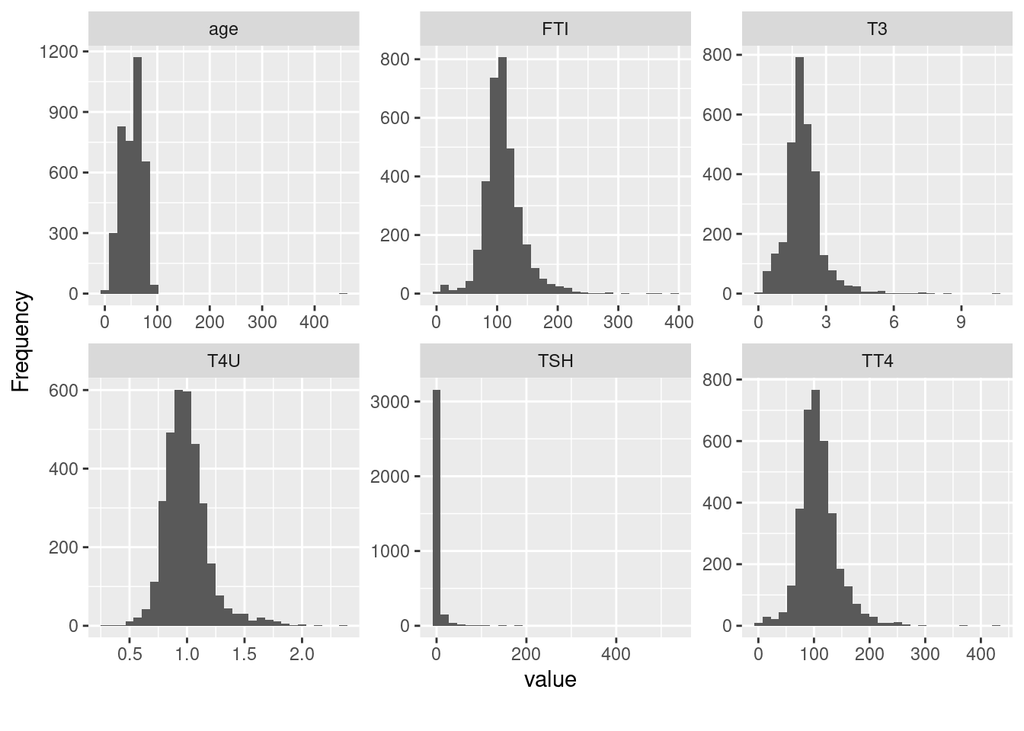

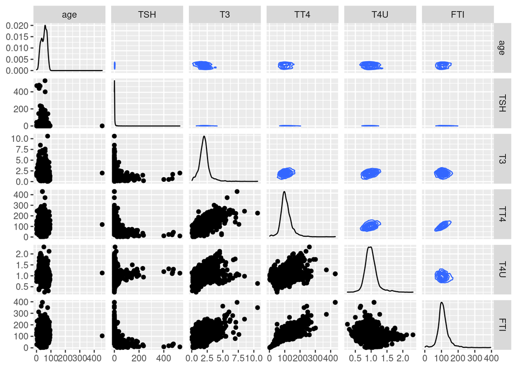

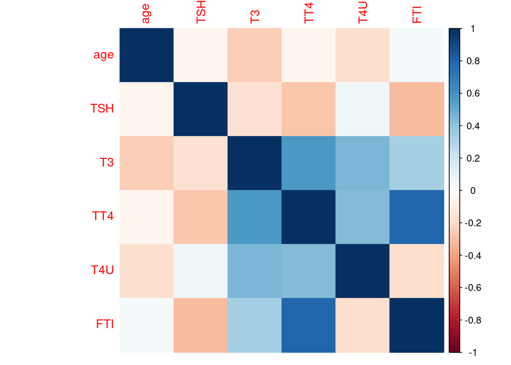

## Rozkłady zmiennych kategorycznych

Większość ze zmiennych kategorycznych to zmienne binarne. Warto zauważyć:

- przewaga kobiet nad mężczyznami
- niezrównoważone liczności w niemal wszystkich zmiennych
- klasa, którą chcemy przewidywać jest mocno niezbilansowana,  
  zdecydowanie przeważają osoby z diagnozą negatywną

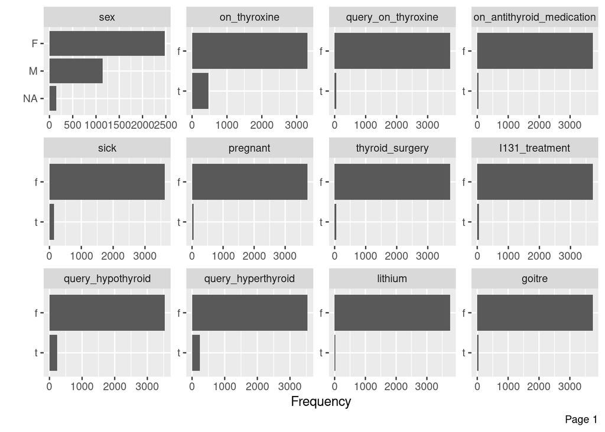

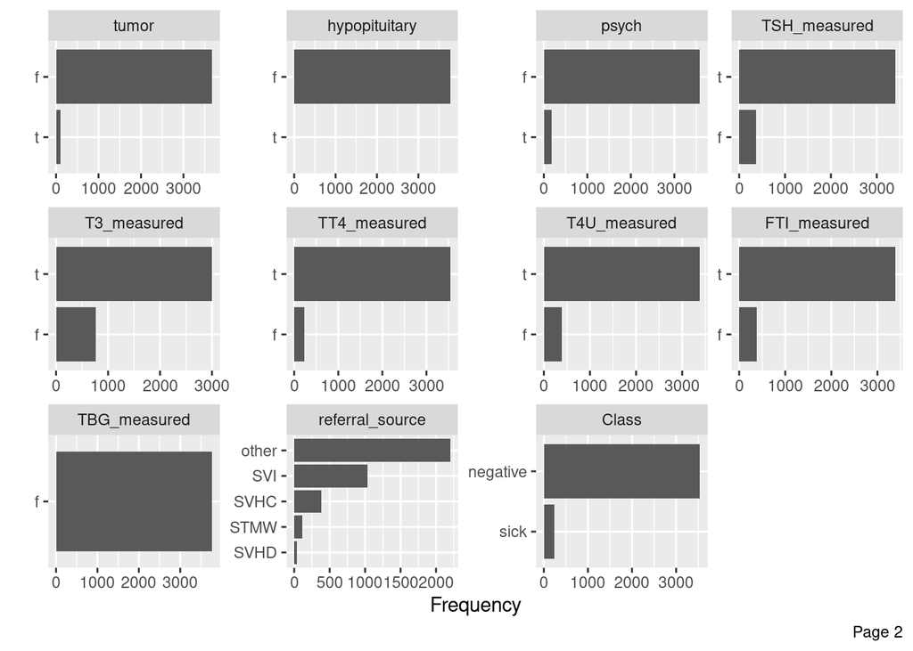

## Zmienne z brakami danych

### Typy zmiennych z brakami danych

Tylko jedna kolumna z brakami dotyczy zmiennej kategorycznej (płeć), pozostałe to zmienne ciągłe. Dodatkowo:

- zmienna TBG jest w całości pusta i mogła zostać usunięta ze zbioru
- w zmiennej ‘age’ występuje dokładnie jeden brak, zdecydowałem o usunięciu tej obserwacji  
  i uznaniu zmiennej ‘age’ za kompletną

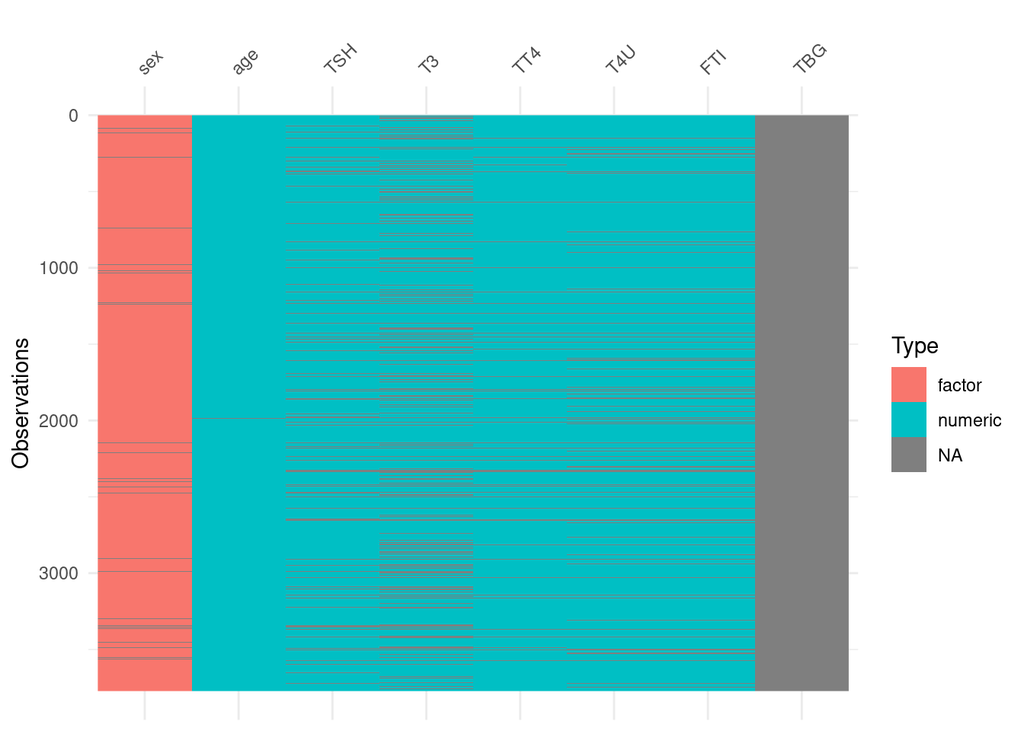

### Procentowy brak danych

Braki danych stanowią istotny odsetek w zmiennych ciągłych gdzie w czterech z nich przekraczają próg około 10%.

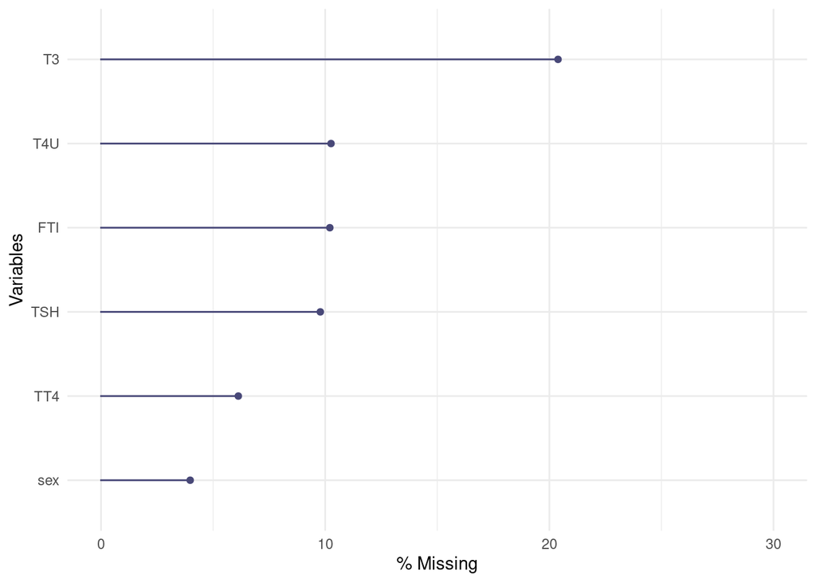

### Wzorce w brakach danych

Można zaobserwować, że istnieje spora grupa przypadków gdzie braki występują jednocześnie we wszystkich pomiarach wskaźników.

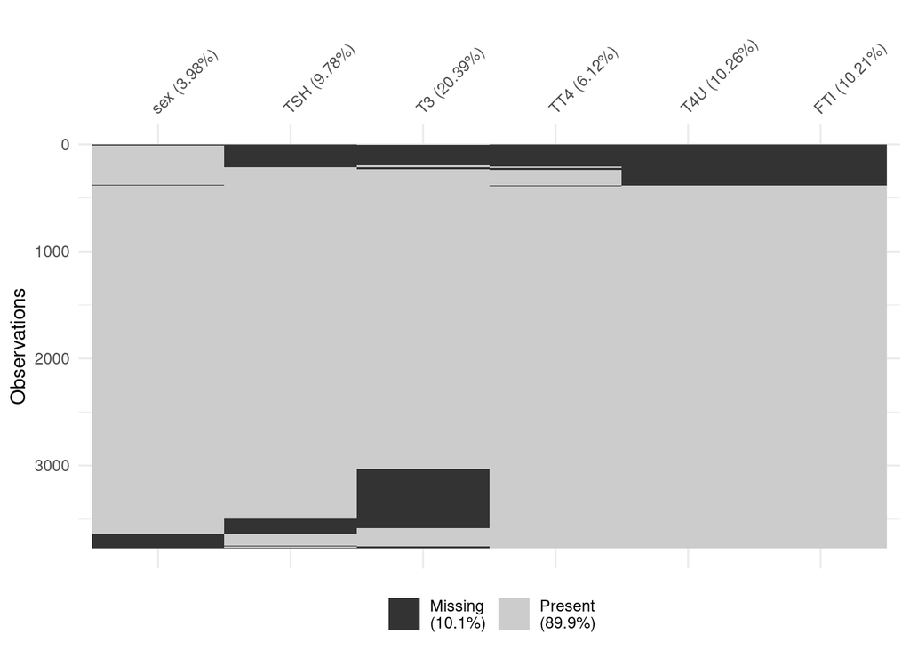

Najwięcej braków danych miało miejsce w zmiennej T3. Względem występowania braku w tej zmiennej rozdzieliłem histogramy pozostałych zmiennych ciągłych. Nie zaobserwowałem żadnych nietypowych zależności.

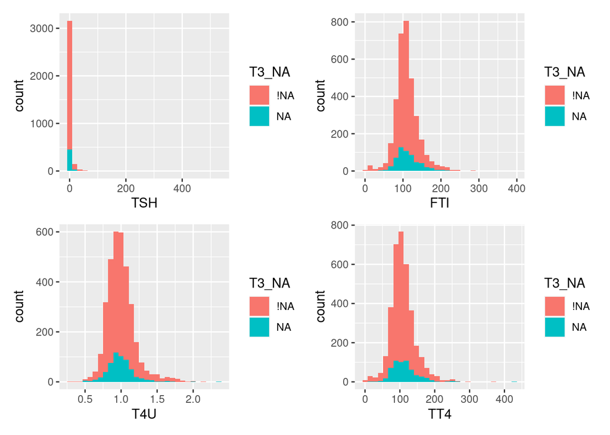

# Imputacja danych i badanie modeli

## Założenia

1. Usunięta zmienna ‘TBG’
2. Usunięta obserwacja z brakiem w zmiennej ‘age’
3. Zastosowanie następujących metod imputacji danych:
- usunięcie obserwacji z minimum jednym brakiem
- usunięcie kolumn zmiennych z brakami danych
- imputacja prosta:  
  zmienna kategoryczna ‘sex’: wprowadzenie dodatkowej kategorii dla braku danych  
  zmienne ciągłe: zastąpienie medianą i zastąpienie średnią

Powyższe techniki połączyłem w 6 wariantów, dodatkowo badając imputację zmiennych ciągłych z usuniętą zmienną kategoryczną.

## Algorytm

Do zbadania wpływu imputacji danych wybrałem algorytm drzewa klasyfikacyjnego.  
Wyniki algorytmu mierzyłem według następującego schematu:

### Przygotowanie do przeprowadzenia testów

```r
df <- sick_task$data

# Usunięcie zmiennej 'TBG'
df <- subset(df, select = -TBG)

# Usunięcie obserwacji z brakiem w 'age'
df <- df[!is.na(df$age),]

# Algorytm
learner = mlr_learners$get("classif.rpart")
learner$predict_type <- 'prob'

#Kroswalidacja
cv = rsmp("cv", folds = 10)

walidacja <- function(task){

  result <- c()

  for (i in c(10:30)) {
    # Strojenie parametru minsplit - domyślnie==20
    cur_learner <- learner
    cur_learner$param_set$values = list(minsplit = i)

    # Przeprowadzenie walidacji
    rr = resample(task, learner, cv)

    # Zapisanie średniej ACC
    result[i] <- mean(rr$score(msr("classif.acc"))$classif.acc)
  }

  # Funkcja zwraca algorytm z najlepszym parametrem
  best_learner <- learner
  best_learner$param_set$values = list(minsplit = which.max(result))

  return(best_learner)
}

# Zapis rezultatów
metoda = c("del_row", "del_var", "median", "mean",
                                 "median_no_sex", "mean_no_sex")
results <- data.frame(accuracy = rep(NA, 6), precision = rep(NA, 6),
                      AUC = rep(NA, 6))
row.names(results) <- metoda

# Miary oceny
accuracy <- msr("classif.acc")
precision <- msr("classif.precision")
auc <- msr("classif.auc")

score <- function(alg, train_s, test_s, task){
  # Trenowanie
  alg$train(task, row_ids = train_s)

  # Predykcja
  prediction <- alg$predict(task, row_ids = test_s)

  # Miary
  acc <- prediction$score(accuracy)
  pr <- prediction$score(precision)
  auc <- prediction$score(auc)

  # Krzywe ROCR
  roc <- autoplot(prediction, type='roc')
  return(c(acc, pr, auc, roc))
}
```

### 1. Usuwanie obserwacji

```r
# Usunięcie obserwacji z minimum jednym brakiem danych
df1 <- df[complete.cases(df),]

# Przygotowanie zadania
task_sick = TaskClassif$new(id = "sick", backend = df1, target = "Class")

train_set = sample(task_sick$nrow, 0.8 * task_sick$nrow)
test_set = setdiff(seq_len(task_sick$nrow), train_set)

# Walidacja
alg <- walidacja(task_sick)

# Trenownie, predykcja, ocena
wynik <- score(alg, train_set, test_set, task_sick)

results["del_row",] <- wynik[1:3]
r1 <- as.data.frame(wynik[4])
```

### 2. Usuwanie zmiennych z brakami

```r
# Usunięcie zmiennych gdzie wystąpiły braki
df2 <- subset(df, select = -c(sex, TSH, T3, TT4, T4U, FTI))

# Przygotowanie zadania
task_sick = TaskClassif$new(id = "sick", backend = df2, target = "Class")

# Ten podział pozostanie niezmionony dla kolejnych metod
train_set = sample(task_sick$nrow, 0.8 * task_sick$nrow)
test_set = setdiff(seq_len(task_sick$nrow), train_set)

# Walidacja
alg <- walidacja(task_sick)

# Trenownie, predykcja, ocena
wynik <- score(alg, train_set, test_set, task_sick)

results["del_var",] <- wynik[1:3]
r2 <- as.data.frame(wynik[4])
```

### 3. Uzupełnienie średnią oraz dodatkowa kategoria dla zmiennej ‘sex’

```r
df3 <- df

# Dodanie kategorii 'u' - nieznana płeć (w miejsce brak danych)
df3$sex <- as.character(df3$sex)
df3$sex[is.na(df3$sex)] <- "u"
df3$sex <- as.factor(df3$sex)

train_set_df <- df3[train_set,]
test_set_df <- df3[test_set,]

# Uzupełnianie średnią zbioru treningowego
for(i in c("TSH", "T3", "TT4", "T4U", "FTI")){
  rows <- is.na(df3[ ,i])
  rows[test_set] <- FALSE
  df3[rows, i] <- mean(train_set_df[,i], na.rm = TRUE)
}

# Uzupełnianie średnią zbioru testowego
for(i in c("TSH", "T3", "TT4", "T4U", "FTI")){
  rows <- is.na(df3[ ,i])
  rows[train_set] <- FALSE
  df3[rows, i] <- mean(test_set_df[,i], na.rm = TRUE)
}

# Przygotowanie zadania
task_sick = TaskClassif$new(id = "sick", backend = df3, target = "Class")

# Walidacja
alg <- walidacja(task_sick)

# Trenownie, predykcja, ocena
wynik <- score(alg, train_set, test_set, task_sick)

results["mean",] <- wynik[1:3]
r3 <- as.data.frame(wynik[4])
```

```r
df4 <- df

# Dodanie kategorii 'u' - nieznana płeć (brak danych)
df4$sex <- as.character(df4$sex)
df4$sex[is.na(df4$sex)] <- "u"
df4$sex <- as.factor(df4$sex)

train_set_df <- df4[train_set,]
test_set_df <- df4[test_set,]

# Uzupełnianie medianą zbioru treningowego
for(i in c("TSH", "T3", "TT4", "T4U", "FTI")){
  rows <- is.na(df4[ ,i])
  rows[test_set] <- FALSE
  df3[rows, i] <- median(train_set_df[,i], na.rm = TRUE)
}

# Uzupełnianie medianą zbioru testowego
for(i in c("TSH", "T3", "TT4", "T4U", "FTI")){
  rows <- is.na(df3[ ,i])
  rows[train_set] <- FALSE
  df3[rows, i] <- mean(test_set_df[,i], na.rm = TRUE)
}

# Przygotowanie zadania
task_sick = TaskClassif$new(id = "sick", backend = df4, target = "Class")

# Walidacja
alg <- walidacja(task_sick)

# Trenownie, predykcja, ocena
wynik <- score(alg, train_set, test_set, task_sick)

results["median",] <- wynik[1:3]
r4 <- as.data.frame(wynik[4])
```

### 5. Usunięcie zmiennej ‘sex’ oraz imputacja średniej

```r
df5 <- df

# Usunięcie zmiennej 'sex'
df5 <- subset(df5, select = -sex)

train_set_df <- df5[train_set,]
test_set_df <- df5[test_set,]

# Uzupełnianie średnią zbioru treningowego
for(i in c("TSH", "T3", "TT4", "T4U", "FTI")){
  rows <- is.na(df5[ ,i])
  rows[test_set] <- FALSE
  df5[rows, i] <- mean(train_set_df[,i], na.rm = TRUE)
}

# Uzupełnianie średnią zbioru testowego
for(i in c("TSH", "T3", "TT4", "T4U", "FTI")){
  rows <- is.na(df5[ ,i])
  rows[train_set] <- FALSE
  df5[rows, i] <- mean(test_set_df[,i], na.rm = TRUE)
}

# Przygotowanie zadania
task_sick = TaskClassif$new(id = "sick", backend = df5, target = "Class")

# Walidacja
alg <- walidacja(task_sick)

# Trenownie, predykcja, ocena
wynik <- score(alg, train_set, test_set, task_sick)

results["mean_no_sex",] <- wynik[1:3]
r5 <- as.data.frame(wynik[4])
```

### 6. Usunięcie zmiennej ‘sex’ oraz imputacja mediany

```r
df6 <- df

# Usunięcie zmiennej 'sex'
df6 <- subset(df6, select = -sex)

train_set_df <- df6[train_set,]
test_set_df <- df6[test_set,]

# Uzupełnianie medianą zbioru treningowego
for(i in c("TSH", "T3", "TT4", "T4U", "FTI")){
  rows <- is.na(df6[ ,i])
  rows[test_set] <- FALSE
  df6[rows, i] <- median(train_set_df[,i], na.rm = TRUE)
}

# Uzupełnianie medianą zbioru testowego
for(i in c("TSH", "T3", "TT4", "T4U", "FTI")){
  rows <- is.na(df6[ ,i])
  rows[train_set] <- FALSE
  df6[rows, i] <- median(test_set_df[,i], na.rm = TRUE)
}

# Przygotowanie zadania
task_sick = TaskClassif$new(id = "sick", backend = df6, target = "Class")

# Walidacja
alg <- walidacja(task_sick)

# Trenownie, predykcja, ocena
wynik <- score(alg, train_set, test_set, task_sick)

results["median_no_sex",] <- wynik[1:3]
r6 <- as.data.frame(wynik[4])
```

# Podsumowanie wyników

### Miary predykcji klas

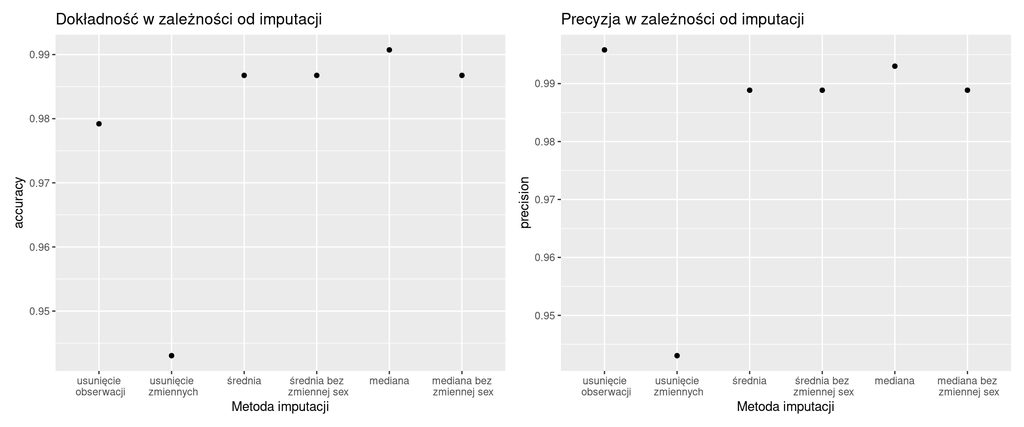

### Miary prawdopodobieństwa

Poza usuwaniem zmiennych, wszystkie metody przyniosły porównywalne i bardzo dobre wyniki. Usuwanie zmiennych przyniosło bardzo negatywny efekt, algorytm osiągnął wynik klasyfikatora losowego.

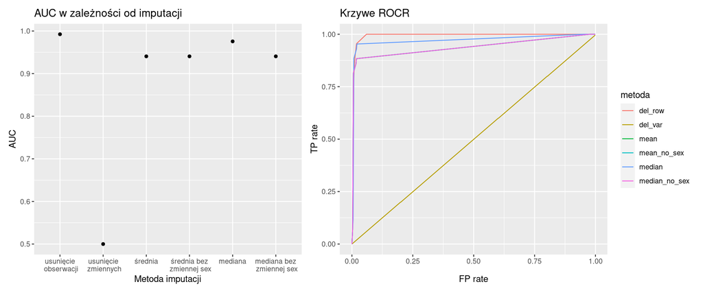

Dokładne wartości osiągniętych miar.

|  | accuracy | precision | AUC |
| --- | --- | --- | --- |
| usunięcie obserwacji | 0.9792060 | 0.9958159 | 0.9924321 |
| usunięcie zmiennych | 0.9430464 | 0.9430464 | 0.5000000 |
| mediana | 0.9907285 | 0.9930070 | 0.9756826 |
| średnia | 0.9867550 | 0.9888579 | 0.9405866 |
| mediana bez zmiennej sex | 0.9867550 | 0.9888579 | 0.9405866 |
| średnia bez zmiennej sex | 0.9867550 | 0.9888579 | 0.9405866 |